# Escherichia coli Data Exploration in the Upper Santa Cruz River

[figure not shown]

[figure not shown]

[figure not shown]

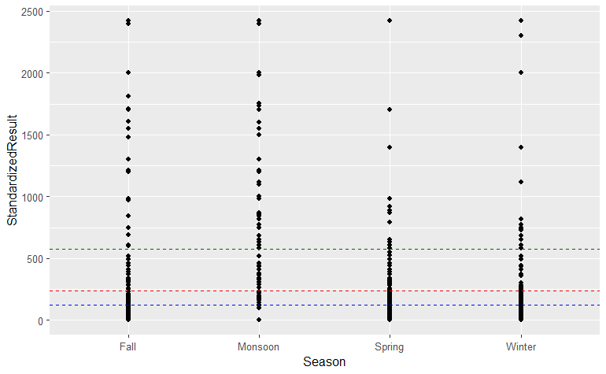

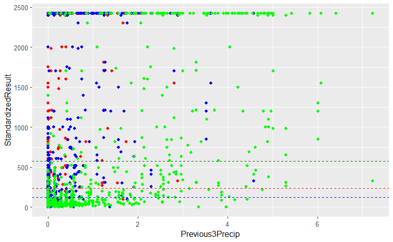

```r
data_Merge2$TOD <- cut(chron::times(timep) , breaks = (1/24) * c(0,5,11,16,19,24))
data_Merge2$TOD <- c(4, 1, 2, 3, 4)[as.numeric(data_Merge2$TOD)]




#The columns are getting messy. Remove duplicates and nulls



# Remove extraneous columns and reorder

# I had previously kept hydrologic condition and event in, but there are so many nulls I don't think it will be worth it. LAURA may be able to attribute the condition (rising or falling) based on the staff gage. Will need to speak to hydrologist.

# Columns are organized so that the "metadata" columns are in the beginning. These will not be used for correlation views.
data_Merge3 <- data_Merge2 %>%
  select(ActivityConductingOrganizationText, MonitoringLocationIdentifier, QuantificationLimit, DailyFlowCount, DateTime2, StandardizedResult, Discharge_CFS, USGS_Staff, QuantificationLimit, Precipitation..in., PreviousTmax, PreviousTmin, Previous3Precip, ThreeDayMin, TenDayMin, ThirtyDayMin, Previous7Precip, Previous30Precip, Season, NinXTS, TOD, Stage, DistFromSonoita)

# Remove old data.
rm(data_Merge, data_Merge2, DailyClimate, Nin, NinXTS)






data_Merge3 %>%
  ggplot(aes(x=Season, y=StandardizedResult)) +
  geom_point() +
  geom_hline(yintercept=126, linetype="dashed",
                color = "blue", size=0.2) +
  geom_hline(yintercept=235, linetype="dashed",
                color = "red", size=0.2)+
  geom_hline(yintercept=575, linetype="dashed",
                color = "dark green", size=0.2)






#Notes on above diagram: Monsoon values seem significantly above blue
line. Winter values have many less maximum values.
#graph this too.



# Missing values are expected.
data_Merge3 %>%
  ggplot() +
  geom_point(aes(x=Previous3Precip, y=StandardizedResult), color = "red") +
  geom_point(aes(x=Previous7Precip, y=StandardizedResult), color = "blue")+
  geom_point(aes(x=Previous30Precip, y=StandardizedResult), color = "green")+
  geom_hline(yintercept=126, linetype="dashed",
                color = "blue", size=0.2) +
  geom_hline(yintercept=235, linetype="dashed",
                color = "red", size=0.2)+
  geom_hline(yintercept=575, linetype="dashed",
                color = "dark green", size=0.2)






I should change the categorical variables back to numeric for
corrplot.
Numerical Categorical swap



data_Merge3$SeasonNumeric <- ifelse(data_Merge3$Season == "Fall", 1,
          ifelse(data_Merge3$Season == "Winter", 2,
          ifelse (data_Merge3$Season =="Spring", 3,4)))



I want to change the organization to numeric as well.
I’d like to look at organization to see if this has any noteworthy
effect on the results. If it appears significant, this could be due to
the time of testing (project funding is more likely when there is an
issue) or due to the personell collecting the data. A strong correlation
will indicate either of these issues.



data_Merge3$ACO_Numeric <- ifelse(data_Merge3$ActivityConductingOrganizationText == "U.S. National Park Service", 1,
   ifelse(data_Merge3$ActivityConductingOrganizationText == "NATIONAL PARK SERVICE", 1,
   ifelse(data_Merge3$ActivityConductingOrganizationText == "Friends of the Santa Cruz River, Tubac, AZ", 2,
   ifelse(data_Merge3$ActivityConductingOrganizationText =="FRIENDS OF THE SANTA CRUZ RIVER", 2,
   ifelse(data_Merge3$ActivityConductingOrganizationText == "U.S. Geological Survey-Water Resources Discipline", 3,
   ifelse(data_Merge3$ActivityConductingOrganizationText == "ARIZONA DEPT OF ENVIRONMENTAL QUALITY", 4,
   ifelse(data_Merge3$ActivityConductingOrganizationText == "INTERNATIONAL BOUNDARY AND WATER COMMISSION", 5,
   ifelse(data_Merge3$ActivityConductingOrganizationText == "UNIVERSITY OF ARIZONA - MARICOPA AGRICULTURAL CENTER", 6,
   ifelse(data_Merge3$ActivityConductingOrganizationText == "HARRIS ENVIRONMENTAL", 7,
   ifelse(data_Merge3$ActivityConductingOrganizationText == "NPS", 8,  # This is SODN data, Separate from other NPS
   ifelse(data_Merge3$ActivityConductingOrganizationText == "VOLUNTEER GROUPS", 9,
          NaN)))))))))))
```

## Begin looking at the correlation

I want to look at nulls from the climate data. I think this will have an effect on my corrplot. With removed rows, I still have ~900 to play with.

```r
data_Merge3 <- na.omit(data_Merge3)
```

Create the classifiers, 126 (FBC, geometric mean, minimum of four samples in 30 days), 235 (FBC, single sample ), 575 (PBC) according to EPA regulations for the state of Arizona.

```r
data_Merge3$ecoli_235 <- ifelse(data_Merge3$StandardizedResult > 234.5,1,0)
data_Merge3$ecoli_575 <- ifelse(data_Merge3$StandardizedResult > 574.5,1,0)
```

Determine how balanced the dataset is.

```r
# Count total rows
totaln <- data_Merge3 %>%
  summarise(n = n())

# Total positive at 235 is currently (10/22) 51.6%
data_Merge3 %>%
  filter(ecoli_235 ==1) %>%
  summarise(n = n())/totaln
```

[output not shown]

```r
# Total positives at 575 is currently (10/22) 42.5%
data_Merge3 %>%
  filter(ecoli_575 ==1) %>%
  summarise(n = n())/totaln
```

[output not shown]

```r
NA
```

## Data Exploration 2.0

Now that I’ve looked at the overall data, make a test and train set to proceed.

```r
# De-randomize (for now, at least).
set.seed(24)

#subset the data by 70%
subset <- sample(nrow(data_Merge3),nrow(data_Merge3) * 0.7)

#create training and test data from subset
traindata <- data_Merge3[subset, ]
testdata <- data_Merge3[-subset, ]
```

Pairs examination Use the *Training* data to train the models. Test data comes in for validation procedures.

```r
# Ensure that only numeric data is contained. There was a previous cleanup but it still contained metadata.
traindata_numeric <- traindata %>%
  select(c("StandardizedResult", "ecoli_235","ecoli_575", "Discharge_CFS", "USGS_Staff", "Precipitation..in.", "PreviousTmax", "PreviousTmin", "Previous3Precip", "Previous7Precip", "Previous30Precip", "NinXTS", "TOD", "Stage", "SeasonNumeric", "ACO_Numeric", "DistFromSonoita", "ThreeDayMin", "TenDayMin", "ThirtyDayMin"))

# I can look at pairs
# Now that I've added more variables this isn't exactly useful.
pairs(traindata_numeric)
```

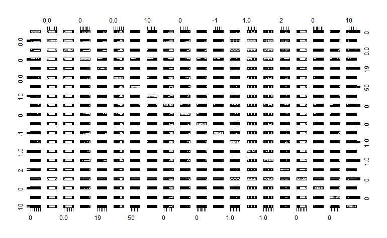

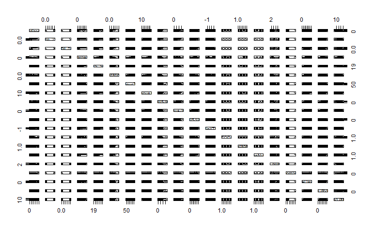

Correlation Matrix

```r
# Create correlation matrix
cor <- cor(traindata_numeric)

corrplot(cor, method = 'square', order = 'FPC', type = 'upper', diag = FALSE, addCoef.col="black", number.cex=0.75)
```

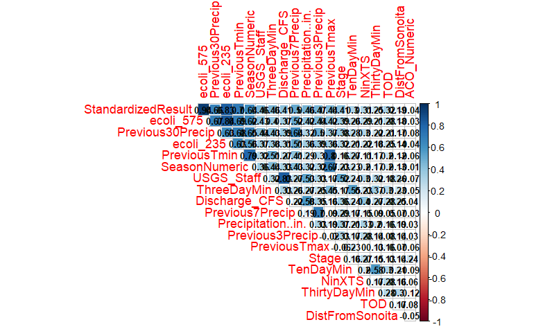

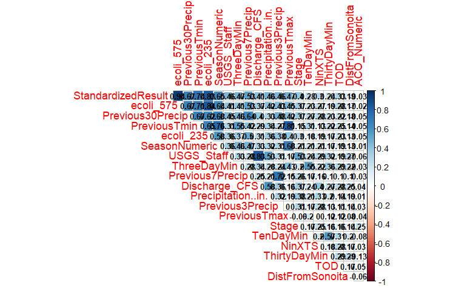

```r
# looking at only ecoli_575
cor2 <- cor(traindata %>%
  select(c("ecoli_575", "Previous30Precip", "PreviousTmin", "Discharge_CFS", "Stage","NinXTS", "TOD","ACO_Numeric", "DistFromSonoita","ThreeDayMin", "TenDayMin", "ThirtyDayMin")))

corrplot(cor2, method = 'square', order = 'FPC', type = 'upper', diag = FALSE, addCoef.col="black", number.cex=0.75)
```

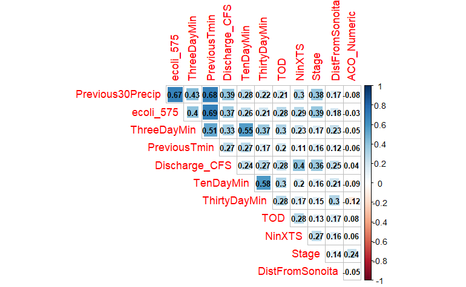

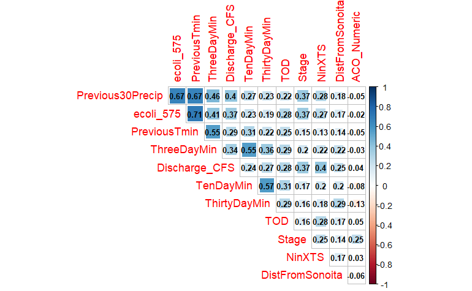

```r
# looking at only ecoli_235
cor3<- cor(traindata %>%
  select(c("ecoli_235", "Previous30Precip", "PreviousTmin", "Discharge_CFS", "Stage","NinXTS", "TOD","ACO_Numeric", "DistFromSonoita","ThreeDayMin", "TenDayMin", "ThirtyDayMin")))

corrplot(cor3, method = 'square', order = 'FPC', type = 'upper', diag = FALSE, addCoef.col="black", number.cex=0.75)
```

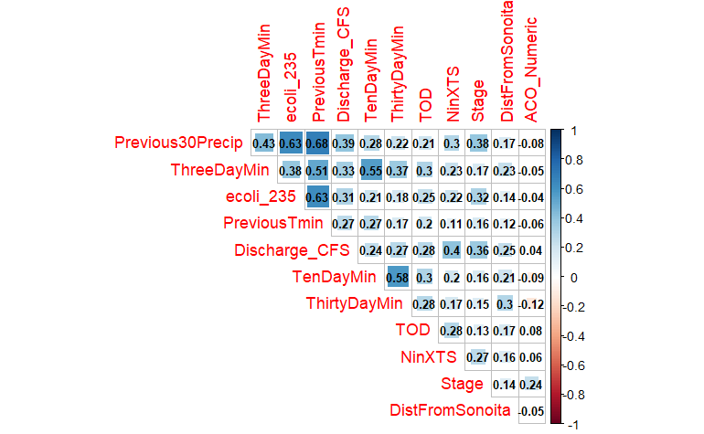

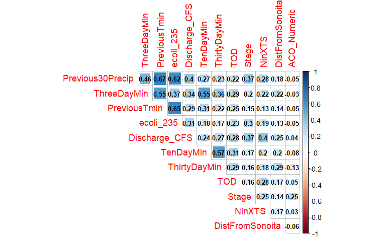

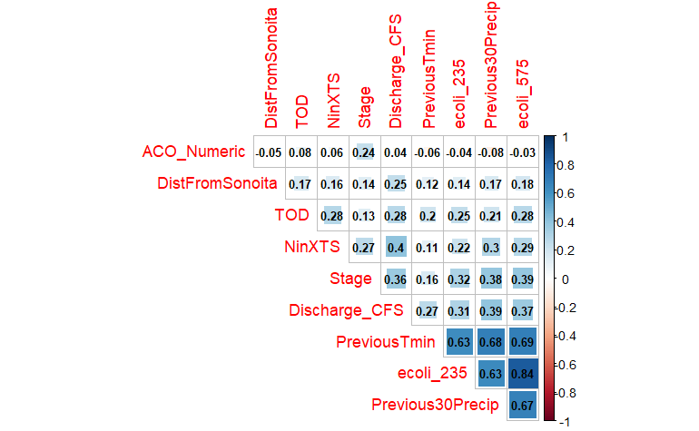

```r
# This looks at both classifications together. Repeat of previous but with limited predictors.
cor4<- cor(traindata %>%
  select(c("ecoli_235", "ecoli_575", "Previous30Precip", "PreviousTmin", "Discharge_CFS", "Stage","NinXTS", "TOD","ACO_Numeric", "DistFromSonoita")))

corrplot(cor4, method = 'square', order = 'FPC', type = 'upper', diag = FALSE, addCoef.col="black", number.cex=0.75)
```

It is important to ensure that I do not include correlated predictors in this model. If I choose a precipitation variable, it should only be one. Same for temperature and discharge/staff.

Season and temperature are also extremely strongly correlated. It may make sense to use only one variable.

# Export data for analysis in python.

```r
write.csv(data_Merge3 %>%
            select("PreviousTmin", "Discharge_CFS", "Stage","NinXTS", "TOD", "DistFromSonoita","ecoli_235", "ecoli_575" ), "Data/Processed/ecoli_attributed2.csv")
```